# OSAC Selection Report Data Viz Options

These are all options. Anything can be tweaked, colors changed, size of things altered, etc. Also, I can get you all the charts as PDFs so you can edit them as you see fit.

One other note: I’m using the [IBM Plex Sans](https://fonts.google.com/specimen/IBM+Plex+Sans?selection.family=IBM+Plex+Sans) font throughout here (because I like it). I couldn’t remember what font you were going to use but just let me know and I can update everything.

# Cover

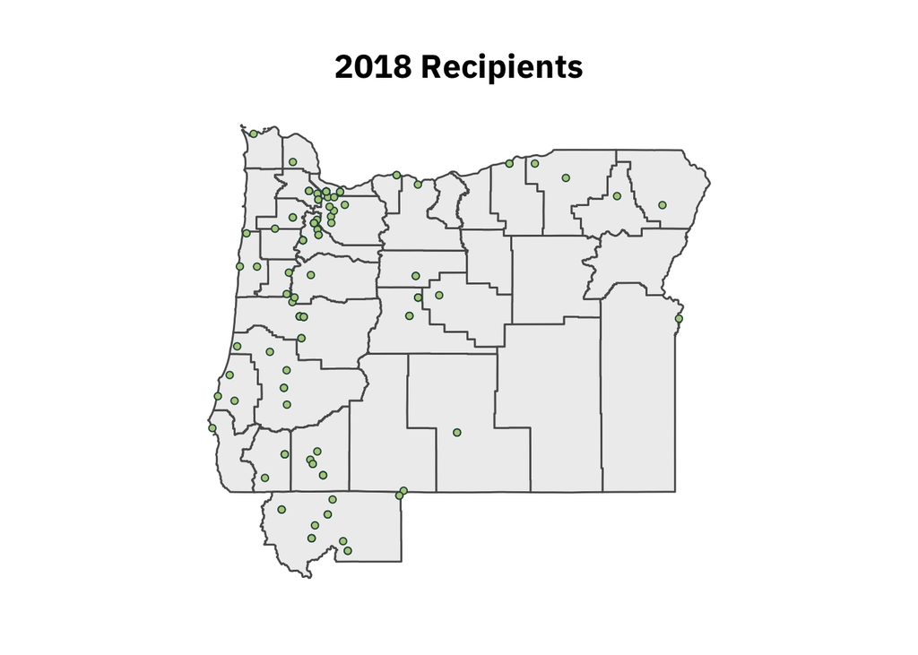

# Region/County

## ‘Dot’ map graphic showing 2018 Applicants by county

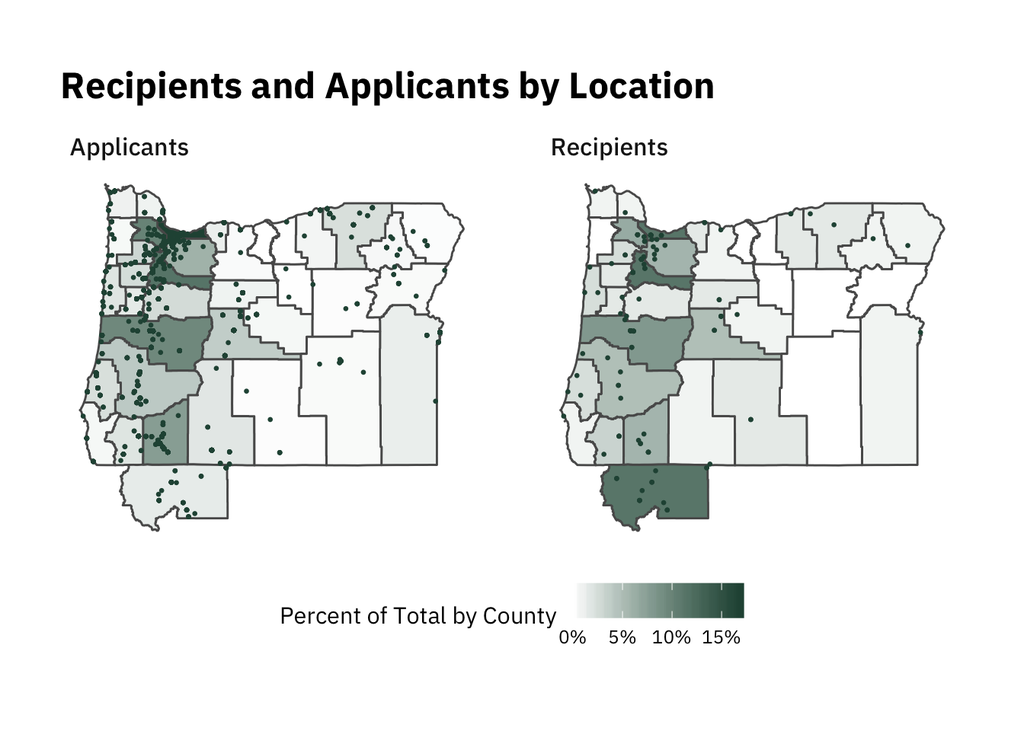

## Pie chart showing what % of 2018 recipients could be considered Rural

Figure shows percent from rural places.

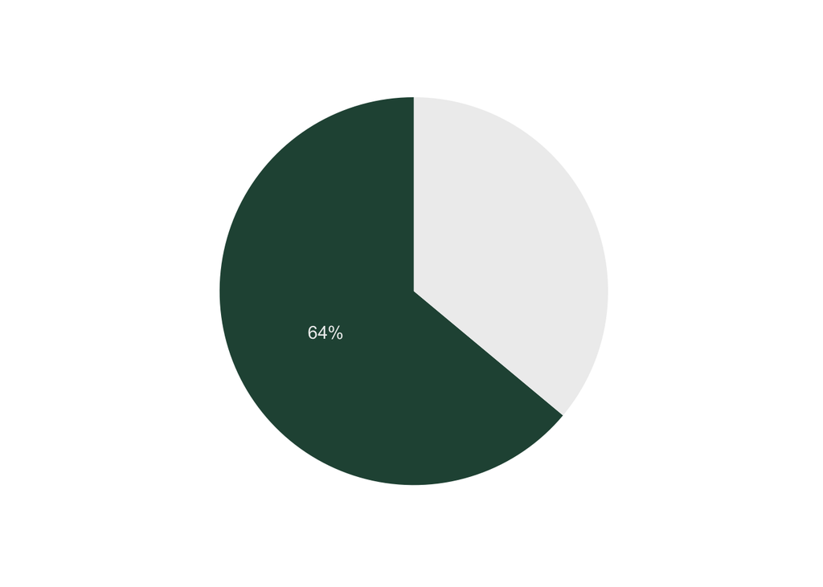

## 5 OR 10 year average % of recipients considered rural

This shows data from last 5 years.

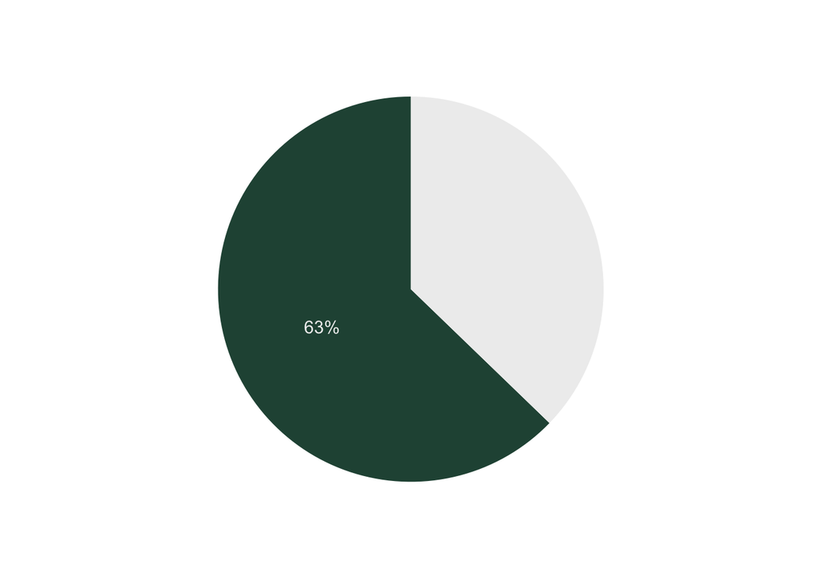

This shows the last 5 years as an area chart.

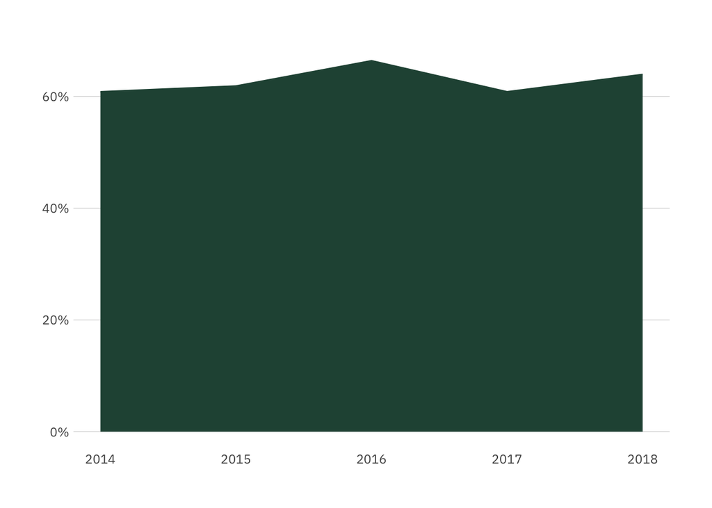

Same data as a line chart.

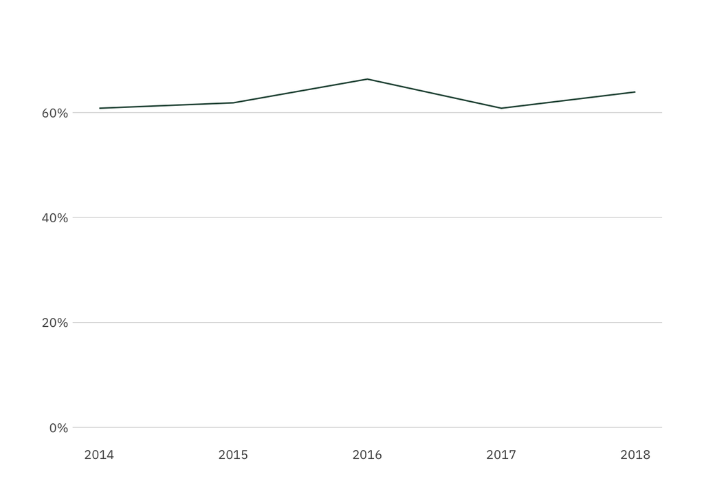

And this shows the last ~25 years as an area chart.

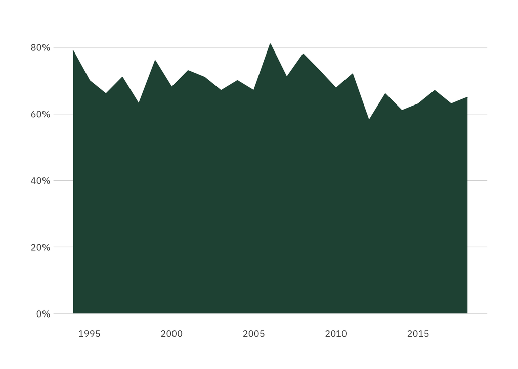

Same data as a line chart.

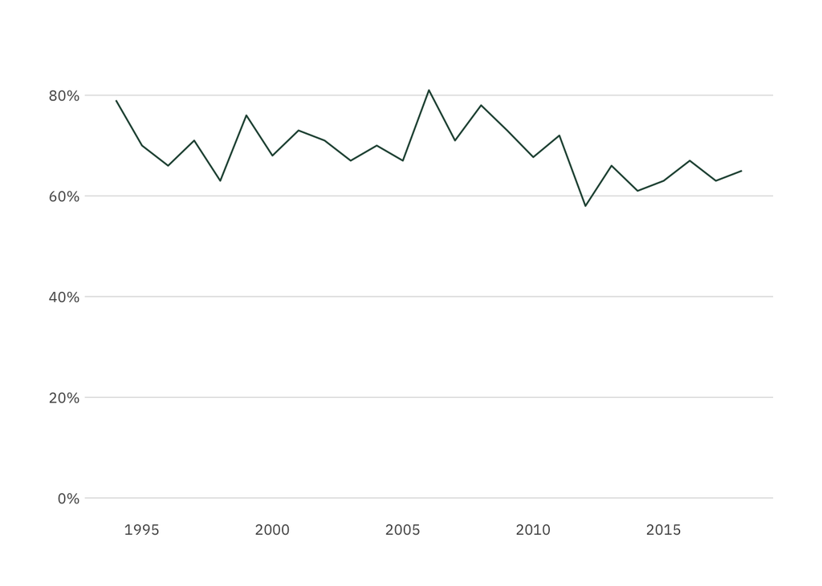

## Siskiyou county callout- What % of CA applicants become recipients VS. what % of OR applicants become recipients

Sorry about the text being small on the Oregon chart. I can adjust this later (or you can edit from the PDF).

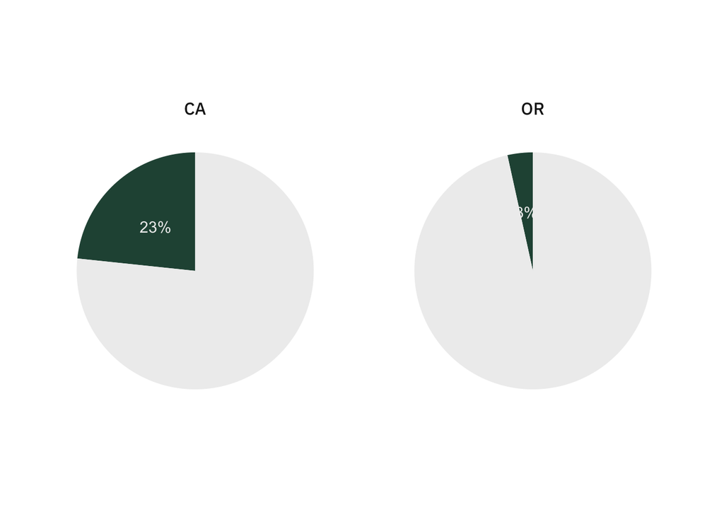

## If there is one or two high schools that have more than 2 recipients- can we call them out here and possible get a quote?

Here are all high schools with 3 or more recipients in 2018.

| High School | Number of Recipients |
| --- | --- |
| Yreka High School | 4 |
| Etna High School | 3 |
| Grant High School | 3 |
| Grants Pass High School | 3 |
| Hillsboro High School | 3 |
| Ridgeview High School | 3 |
| Silverton High School | 3 |
| Tigard High School | 3 |

# Gender

## Pie Chart 2018 Applicants + Recipients by gender

This shows all genders, but you may want to highlight just males since I know the board cares about that in particular.

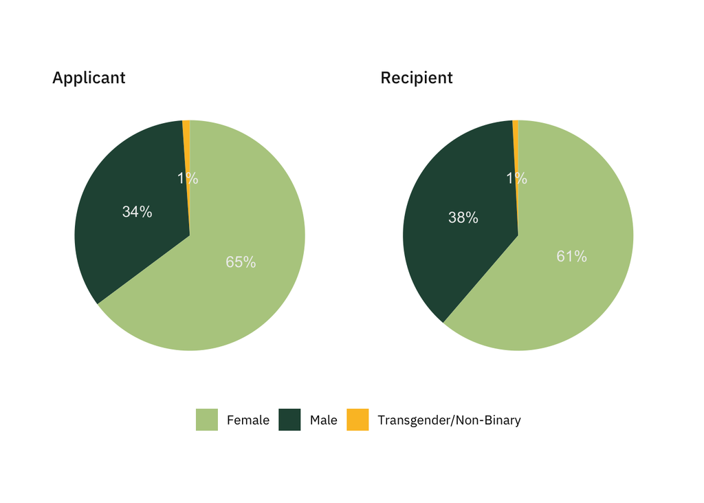

This chart is the same, but just highlights males.

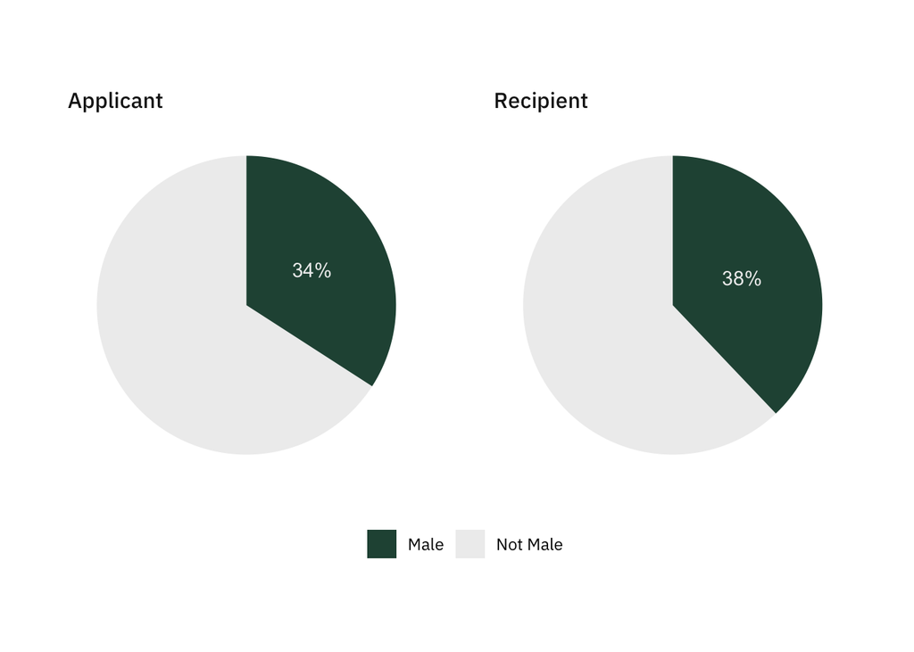

## Stacked Column bar chart showing gender over the last 10 years

I only have the data for males. I also only have the 2017 Excel spreadsheet so this shows data from 1994-2017.

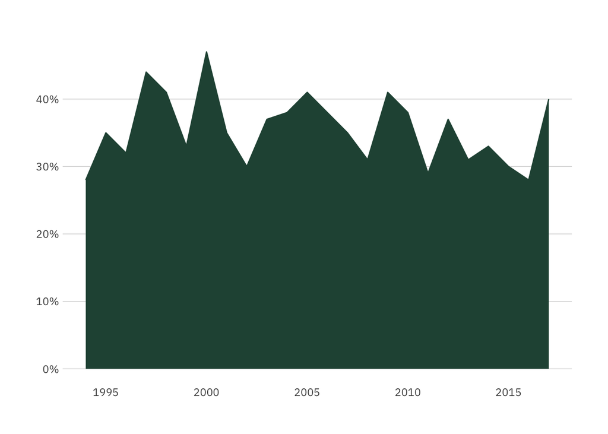

# Race/Ethnicity

## Pie chart showing Ethnicity of 2018 applicants + interviewees + recipients

This shows the percent non-white for each group.

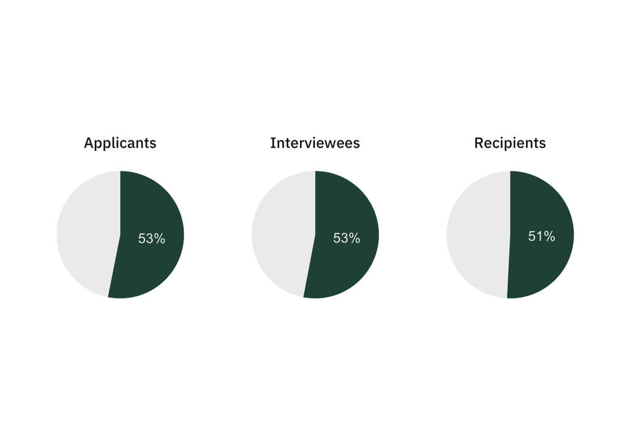

## Line Graph comparing latino recipients over the last 10 years compared to the STATE Latino population (if data is available)

It’s proving a bit more challenging to get the state data than I had hoped. If you really want to include it, I can keep digging. If not, let’s leave it for now.

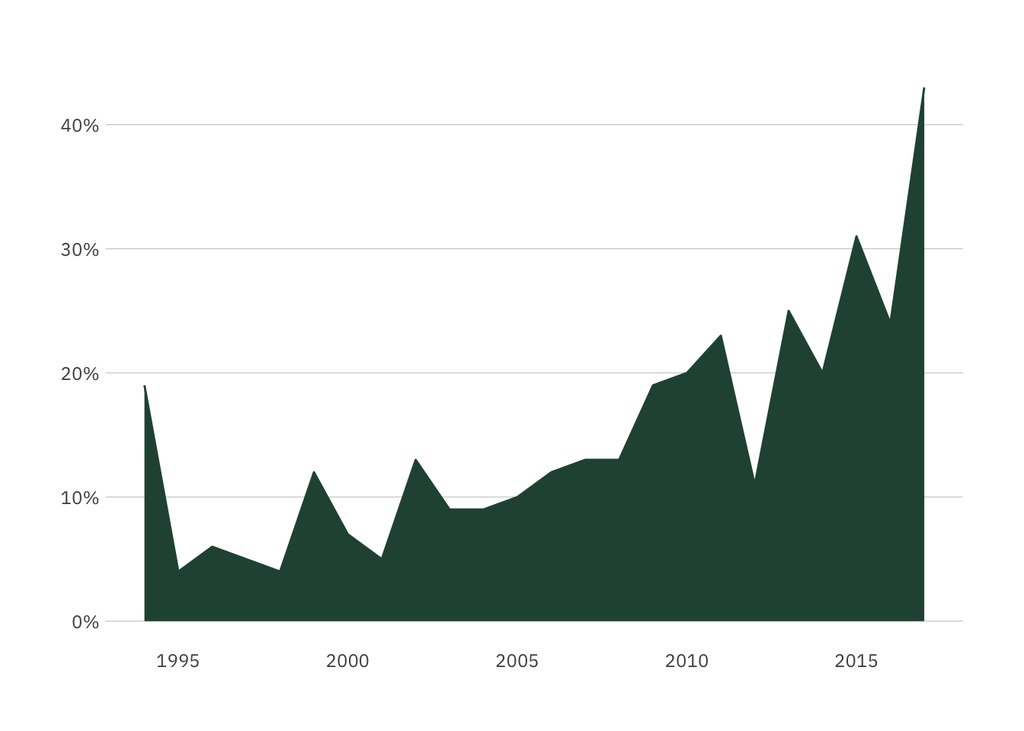

# First Generation/EFC

## Percentage of 2018 applicants + recipients who are First Generation

Figure shows % of students who are first gen.

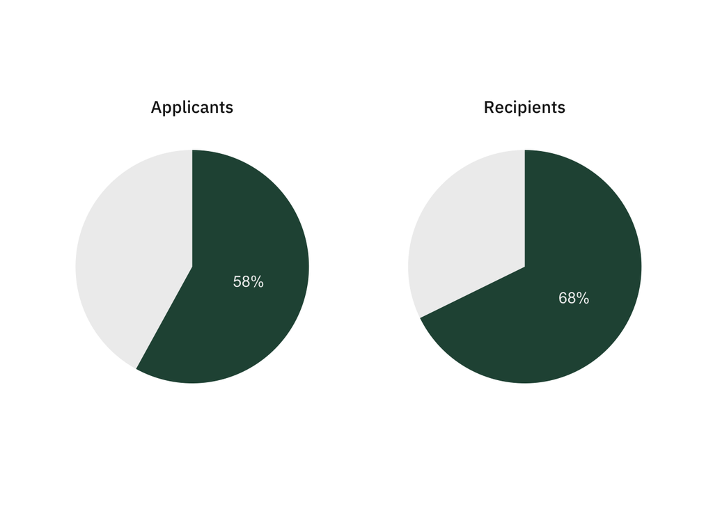

## Statement about 10 year average of first gen recipients

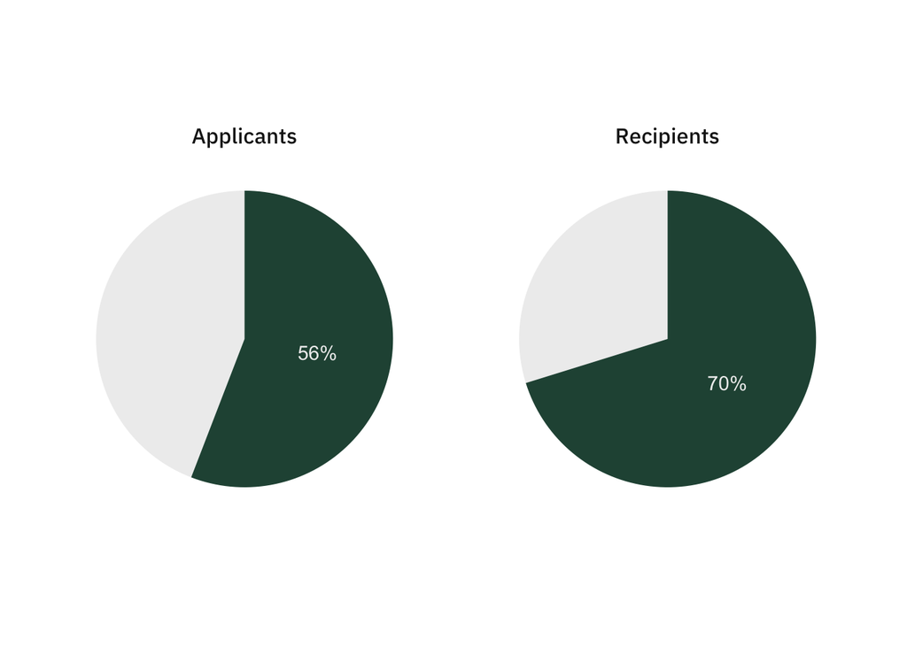

## Table on Expected Family Contribution

This is only for 2018. I showed this to two decimal places (otherwise several items round to 0 percent), though I’d not suggest doing this in the final report because I think this is more detail than people need. I’d put anything super small as “less than 1%”.

| EFC Level | Applicant | Recipient |
| --- | --- | --- |
| $0-$1000 | 62.38% (1947) | 62.90% (78) |
| $1000-$2000 | 9.68% (302) | 6.45% (8) |
| $2000-$3000 | 8.65% (270) | 8.87% (11) |
| $3000-$4000 | 6.98% (218) | 4.84% (6) |
| $4000-$5000 | 6.47% (202) | 8.06% (10) |
| $5000-$6000 | 5.64% (176) | 8.06% (10) |
| $6000-$7000 | 0.06% (2) | 0.00% (0) |
| $7000-$8000 | 0.03% (1) | 0.00% (0) |
| $8000-$9000 | 0.03% (1) | 0.81% (1) |
| $10000-$11000 | 0.03% (1) | 0.00% (0) |
| $15000-$16000 | 0.03% (1) | 0.00% (0) |

# Back Page

## Rural

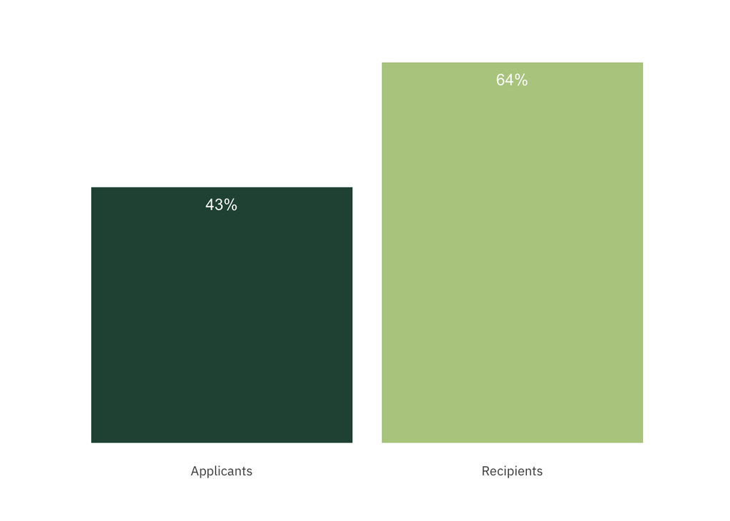

## Gender

This chart just shows % of males.

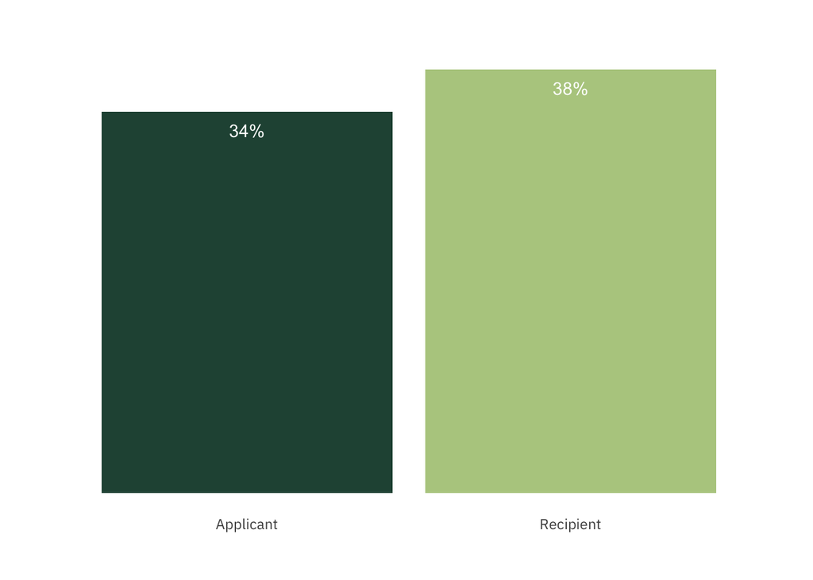

## First Generation

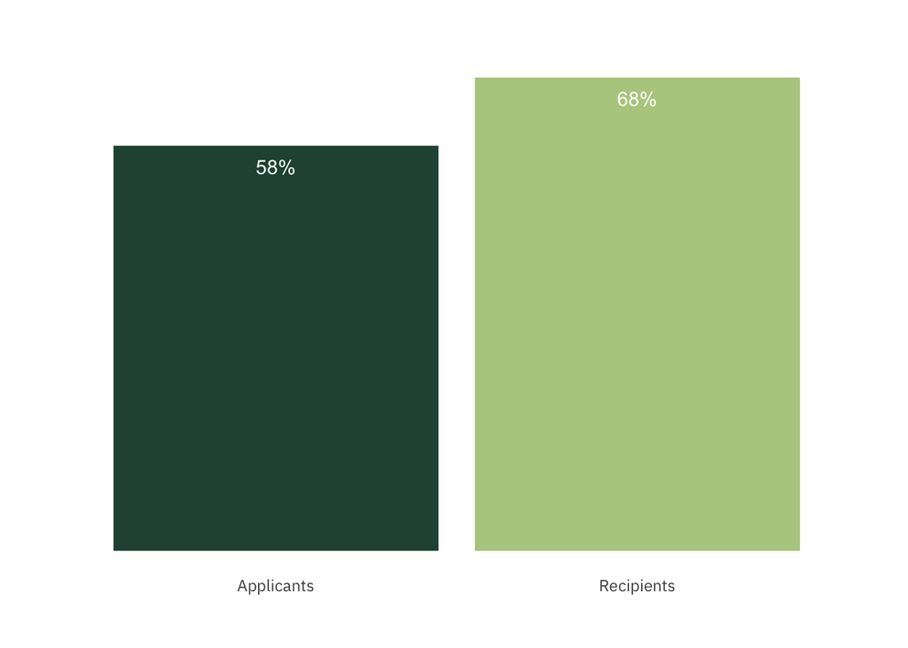

## EFC Contribution

The data for this isn’t exact numbers (it’s, for example, $0-$1000) so we need to figure out how to show this. It could be, say, $2000 or less.

## Average GPA & SAT (maybe this is in one table)

### Math SAT

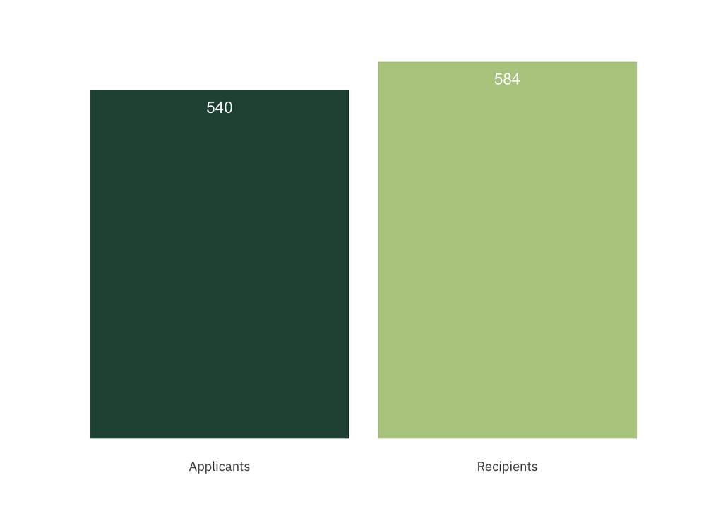

### Verbal SAT

[figure not shown]

### HS GPA

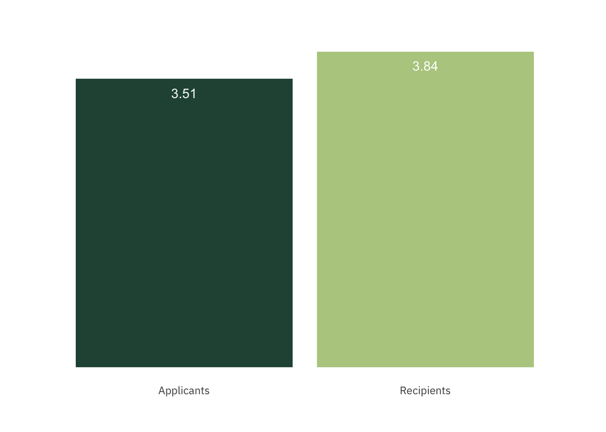